# PART 2: MODEL BUILDING AND SELECTION

## The story:

The business opportunity has been defined and you have come to an agreement with leadership with respect to appropriate wording and testable hypotheses. This part of the case study will focus on the next two stages in the enterprise workflow, namely data transformations and models. This part of the workflow will be treated slightly differently than previous case studies as these are time-series data, but the general procedure and best practices remain the same. These materials will provide the necessary guidance so that you can apply one of the supervised learning approaches that we have already discussed. However, you will also be encouraged to explore some of the time-series modeling tools available.

Time-series data are commonly encountered in data science. In particular, the field of finance, signal processing, weather and other fields regularly deal with data formatted in this way. The goal of this case study is time-series forecasting, which can be thought of as the use of a model to predict future values based on previously observed values. So we could try to predict purchases, number of views or the feature most closely related to our business opportunity, revenue.

## Tasks

- State the different modeling approaches that you will compare to address the business opportunity.
- Iterate on your suite of possible models by modifying data transformations, pipeline architectures, hyperparameters and other relevant factors.
- Re-train your model on all of the data using the selected approach and prepare it for deployment.
- Articulate your findings in a summary report.

```python
from scripts.model import *
```

## 1. MODEL APPROACHES

The goal is to predict the next point in time (reasonable value for next month's revenue).

Some of the most common tools for time-series analyses:

- Autoregressive models (AR)
- Vector autoregressive models (VAR)
- Univariate moving average models (ARMA)

In this project, we will use an approach of data aggregation (of previous time windows) to train several supervised regression approaches to predict the next 30-day window revenue.

- Random Forest Regressor (`'rf'`)
- Support Vector Regression (`'svr'`)
- K-Neighbors Regression (`'knr'`)
- Linear Regression (`'lr'`)

## 2. MODEL ITERATIONS

Starting with the data from the country of most revenue:

```python
# We use helper function engineer_features with ts_all dataframe
ts_uk = ts_all['united_kingdom']
print(ts_uk.shape)
```

```
(607, 7)
```

### Feature engineering

For each day, the following features are captured:

For X (feature matrix)

- Sum of the revenue of the previous 7, 14, 28, 70 days.
- The sum of the previous year data (capture monthly trend)
- Non-revenue features from last month: mean of `recent_invoices` and `recent_views`.

For y (the predicted variable):

- Sum of the revenue for the next 30 days.

```python
X, y, dates = engineer_features(ts_uk)

print(X.shape)
X.head()
```

```
(549, 7)
```

|  | previous_7 | previous_14 | previous_28 | previous_70 | previous_year | recent_invoices | recent_views |
| --- | --- | --- | --- | --- | --- | --- | --- |
| 0 | 13281.12 | 13281.12 | 13281.12 | 13281.12 | 0.0 | 5.500000 | 461.500000 |
| 1 | 26504.09 | 26504.09 | 26504.09 | 26504.09 | 0.0 | 9.620690 | 916.275862 |
| 2 | 39445.59 | 39445.59 | 39445.59 | 39445.59 | 0.0 | 14.100000 | 1393.833333 |
| 3 | 48608.66 | 48608.66 | 48608.66 | 48608.66 | 0.0 | 17.433333 | 1782.233333 |
| 4 | 49871.94 | 49871.94 | 49871.94 | 49871.94 | 0.0 | 18.466667 | 1885.600000 |

### Model training (using part of UK's ts data)

- Split data in train/test (0.25 test, 0.75 train)
- Use GridSearch cross-validation to train a Random Regressor model (using aggregated features to predict y, next 30-day revenue).

```python
# Train model on a data sampel

n_samples = int(np.round(0.3 * X.shape[0]))
subset_indices = np.random.choice(np.arange(X.shape[0]),n_samples,
                                          replace=False).astype(int)

mask = np.in1d(np.arange(y.size),subset_indices)
y=y[mask]
X=X[mask]
dates=dates[mask]
print('... selected subset of {} for model training'.format(n_samples))

# Train a random forest model
X_train, X_test, y_train, y_test = train_test_split(X, y, test_size=0.25,
                                                        shuffle=True, random_state=42)

param_grid_rf = {'rf__criterion': ['mse','mae'],
                 'rf__n_estimators': [10,15,20,25]}

pipe_rf = Pipeline(steps=[('scaler', StandardScaler()),
                          ('rf', RandomForestRegressor())])

grid = GridSearchCV(pipe_rf, param_grid=param_grid_rf, cv=5, n_jobs=-1)
grid.fit(X_train, y_train)
y_pred = grid.predict(X_test)
eval_rmse =  round(np.sqrt(mean_squared_error(y_test,y_pred)))
print('... training model RMSE: {}'.format(eval_rmse))

print('...  retraining model using with the whole sample data')
grid.fit(X, y)
```

```
... selected subset of 165 for model training
... training model RMSE: 41465
...  retraining model using with the whole sample data
```

```
GridSearchCV(cv=5,
             estimator=Pipeline(steps=[('scaler', StandardScaler()),
                                       ('rf', RandomForestRegressor())]),
             n_jobs=-1,
             param_grid={'rf__criterion': ['mse', 'mae'],
                         'rf__n_estimators': [10, 15, 20, 25]})
```

```python
# Automatize with function: for 'united_kindgom' and 'all'

## Train model for UK and all
model_train(DATA_DIR, test=True)
```

```
... test flag on
...... subseting data
...... subseting countries
... loading ts data from files
... saving test version of model: models/test-rf-united_kingdom-0_1.joblib
... saving test version of model: models/test-rf-all-0_1.joblib
```

```python
## Load saved model
grid = joblib.load('models/test-rf-united_kingdom-0_1.joblib')
y_pred = grid.predict(X_test)
eval_rmse =  round(np.sqrt(mean_squared_error(y_test,y_pred)))
print('... training model RMSE: {}'.format(eval_rmse))
```

```
... training model RMSE: 24888
```

We see that the RMSE is changing over model iterations.

```python
## Check different versions
log_file = pd.read_csv(os.path.join('logs',
                             'train-test-united_kingdom.log'))

display(log_file)
```

|  | unique_id | timestamp | tag | smodel | test_data | x_shape | eval_test | model_version | model_version_note | runtime |
| --- | --- | --- | --- | --- | --- | --- | --- | --- | --- | --- |
| 0 | a811163b-a8cf-4264-bf00-7313096b7856 | 1.621274e+09 | united_kingdom | rf | True | ('2017-11-30', '2019-05-28') | {'rmse': 30147} | 0.1 | supervised learning model for time-series | 000:00:02 |

## 3. Re-train with all data: compare several clfs.

```python
## Train model on all data ('sl', supervised learning)

clfs = ['rf', 'svr', 'knr', 'lr']
for clf in clfs:
    model_train(DATA_DIR, smodel=clf,test=False)
```

```
... loading ts data from files
... saving model: models/sl-rf-portugal-0_1.joblib
... saving model: models/sl-rf-united_kingdom-0_1.joblib
... saving model: models/sl-rf-hong_kong-0_1.joblib
... saving model: models/sl-rf-eire-0_1.joblib
... saving model: models/sl-rf-spain-0_1.joblib
... saving model: models/sl-rf-france-0_1.joblib
... saving model: models/sl-rf-singapore-0_1.joblib
... saving model: models/sl-rf-all-0_1.joblib
... saving model: models/sl-rf-norway-0_1.joblib
... saving model: models/sl-rf-germany-0_1.joblib
... saving model: models/sl-rf-netherlands-0_1.joblib
... loading ts data from files
... saving model: models/sl-svr-portugal-0_1.joblib
... saving model: models/sl-svr-united_kingdom-0_1.joblib
... saving model: models/sl-svr-hong_kong-0_1.joblib
... saving model: models/sl-svr-eire-0_1.joblib
... saving model: models/sl-svr-spain-0_1.joblib
... saving model: models/sl-svr-france-0_1.joblib
... saving model: models/sl-svr-singapore-0_1.joblib
... saving model: models/sl-svr-all-0_1.joblib
... saving model: models/sl-svr-norway-0_1.joblib
... saving model: models/sl-svr-germany-0_1.joblib
... saving model: models/sl-svr-netherlands-0_1.joblib
... loading ts data from files
... saving model: models/sl-knr-portugal-0_1.joblib
... saving model: models/sl-knr-united_kingdom-0_1.joblib
... saving model: models/sl-knr-hong_kong-0_1.joblib
... saving model: models/sl-knr-eire-0_1.joblib
... saving model: models/sl-knr-spain-0_1.joblib
... saving model: models/sl-knr-france-0_1.joblib
... saving model: models/sl-knr-singapore-0_1.joblib
... saving model: models/sl-knr-all-0_1.joblib
... saving model: models/sl-knr-norway-0_1.joblib
... saving model: models/sl-knr-germany-0_1.joblib
... saving model: models/sl-knr-netherlands-0_1.joblib
... loading ts data from files
... saving model: models/sl-lr-portugal-0_1.joblib
... saving model: models/sl-lr-united_kingdom-0_1.joblib
... saving model: models/sl-lr-hong_kong-0_1.joblib
... saving model: models/sl-lr-eire-0_1.joblib
... saving model: models/sl-lr-spain-0_1.joblib
... saving model: models/sl-lr-france-0_1.joblib
... saving model: models/sl-lr-singapore-0_1.joblib
... saving model: models/sl-lr-all-0_1.joblib
... saving model: models/sl-lr-norway-0_1.joblib
... saving model: models/sl-lr-germany-0_1.joblib
... saving model: models/sl-lr-netherlands-0_1.joblib
```

All these functionalities are implemented in `model.py` script.

```python
# Test predict: of all countries
country='all'
year='2018'
month='01'
day='05'
result = model_predict(country,year,month,day)
print(result)
```

```
...Using all data and models from cs-train/ts-* and models/sl-*
... loading ts data from files
{'y_pred': array([184414.794]), 'y_proba': None}
```

```python
# Test predict: on one country
country='germany'
year='2018'
month='01'
day='05'
result = model_predict(country,year,month,day)
print(result)
```

```
...Using all data and models from cs-train/ts-* and models/sl-*
... loading ts data from files
{'y_pred': array([2333.8152]), 'y_proba': None}
```

## 4. Summary report

```python
log_list = glob.glob(os.path.join(LOG_DIR, "train-*.log"))

train_logs = pd.DataFrame()

for f in log_list:
    log = pd.read_csv(f)
    train_logs= pd.concat([train_logs, log], axis=0, ignore_index=True)

print("... {} models where trained".format(train_logs.shape[0]))
display(train_logs)
```

```
... 46 models where trained
```

|  | unique_id | timestamp | tag | smodel | test_data | x_shape | eval_test | model_version | model_version_note | runtime |
| --- | --- | --- | --- | --- | --- | --- | --- | --- | --- | --- |
| 0 | 47b5d479-2cd1-4591-a9bb-806d4c4567e4 | 1.621274e+09 | all | rf | True | ('2017-12-03', '2019-05-25') | {'rmse': 38461} | 0.1 | supervised learning model for time-series | 000:00:02 |
| 1 | d8ff7280-f269-4c75-9363-16f5879aa080 | 1.621274e+09 | portugal | rf | False | ('2017-11-29', '2019-05-31') | {'rmse': 235} | 0.1 | supervised learning model for time-series | 000:00:03 |
| 2 | a0b96f85-ea33-4861-82cb-ef12a0a2ad27 | 1.621274e+09 | portugal | svr | False | ('2017-11-29', '2019-05-31') | {'rmse': 1438} | 0.1 | supervised learning model for time-series | 000:00:02 |
| 3 | d582efa5-2fe0-482d-a9ad-31ade4d09bcb | 1.621274e+09 | portugal | knr | False | ('2017-11-29', '2019-05-31') | {'rmse': 613} | 0.1 | supervised learning model for time-series | 000:00:02 |
| 4 | b3a1dbc6-dd53-400c-a2a4-adfa7177e0df | 1.621274e+09 | portugal | lr | False | ('2017-11-29', '2019-05-31') | {'rmse': 1443} | 0.1 | supervised learning model for time-series | 000:00:02 |
| 5 | d53849f4-3f04-40e5-8a84-3ac9f77f9a71 | 1.621274e+09 | spain | rf | False | ('2017-12-01', '2019-05-31') | {'rmse': 234} | 0.1 | supervised learning model for time-series | 000:00:03 |
| 6 | babe828b-e025-4a80-9115-96a0d03333a3 | 1.621274e+09 | spain | svr | False | ('2017-12-01', '2019-05-31') | {'rmse': 753} | 0.1 | supervised learning model for time-series | 000:00:02 |
| 7 | 7890e7e5-1b6b-4014-8f40-df7d6c011995 | 1.621274e+09 | spain | knr | False | ('2017-12-01', '2019-05-31') | {'rmse': 237} | 0.1 | supervised learning model for time-series | 000:00:02 |
| 8 | 7d2cdec5-0d75-410f-952a-232bb34fcadf | 1.621274e+09 | spain | lr | False | ('2017-12-01', '2019-05-31') | {'rmse': 754} | 0.1 | supervised learning model for time-series | 000:00:01 |
| 9 | 96de5401-45dc-476a-b966-269b45a9d622 | 1.621274e+09 | germany | rf | False | ('2017-11-29', '2019-05-31') | {'rmse': 497} | 0.1 | supervised learning model for time-series | 000:00:03 |
| 10 | 1bf60af1-5fbf-4b73-95aa-ac1e90e5ea23 | 1.621274e+09 | germany | svr | False | ('2017-11-29', '2019-05-31') | {'rmse': 897} | 0.1 | supervised learning model for time-series | 000:00:02 |
| 11 | 8509e32c-d1d5-4ef8-be96-927564adf931 | 1.621274e+09 | germany | knr | False | ('2017-11-29', '2019-05-31') | {'rmse': 432} | 0.1 | supervised learning model for time-series | 000:00:01 |
| 12 | fdb23043-704e-4f2e-a11e-27e3dab57dbe | 1.621274e+09 | germany | lr | False | ('2017-11-29', '2019-05-31') | {'rmse': 902} | 0.1 | supervised learning model for time-series | 000:00:02 |
| 13 | b51da00f-009a-40a5-ae83-6b7da8863445 | 1.621274e+09 | norway | rf | False | ('2017-12-05', '2019-05-11') | {'rmse': 65} | 0.1 | supervised learning model for time-series | 000:00:02 |
| 14 | 48efa234-9204-4791-af18-4ee39c0cf119 | 1.621274e+09 | norway | svr | False | ('2017-12-05', '2019-05-11') | {'rmse': 373} | 0.1 | supervised learning model for time-series | 000:00:01 |
| 15 | ef46ed34-f7c9-41d2-b039-4bf5fab098cc | 1.621274e+09 | norway | knr | False | ('2017-12-05', '2019-05-11') | {'rmse': 43} | 0.1 | supervised learning model for time-series | 000:00:01 |
| 16 | 9132a6fa-c083-43c1-864b-fb6b53091593 | 1.621274e+09 | norway | lr | False | ('2017-12-05', '2019-05-11') | {'rmse': 374} | 0.1 | supervised learning model for time-series | 000:00:01 |
| 17 | 0f080b16-9d7f-4a31-abcc-248375508a59 | 1.621274e+09 | singapore | rf | False | ('2018-04-25', '2019-05-12') | {'rmse': 3679} | 0.1 | supervised learning model for time-series | 000:00:01 |
| 18 | 170a0570-c69b-4116-8498-da0f0fa84072 | 1.621274e+09 | singapore | svr | False | ('2018-04-25', '2019-05-12') | {'rmse': 4226} | 0.1 | supervised learning model for time-series | 000:00:01 |
| 19 | fc5fc3b9-9138-47b1-97ab-0208781ca0f5 | 1.621274e+09 | singapore | knr | False | ('2018-04-25', '2019-05-12') | {'rmse': 2519} | 0.1 | supervised learning model for time-series | 000:00:01 |
| 20 | 5ef729dc-9139-417b-b2ad-c38bcc38d367 | 1.621274e+09 | singapore | lr | False | ('2018-04-25', '2019-05-12') | {'rmse': 4238} | 0.1 | supervised learning model for time-series | 000:00:01 |
| 21 | 6d49bae1-e7b0-441d-a145-26c9944e79da | 1.621274e+09 | hong_kong | rf | False | ('2018-04-19', '2019-05-01') | {'rmse': 852} | 0.1 | supervised learning model for time-series | 000:00:01 |
| 22 | 50967872-e48c-4b89-b0c4-c87278186e48 | 1.621274e+09 | hong_kong | svr | False | ('2018-04-19', '2019-05-01') | {'rmse': 1673} | 0.1 | supervised learning model for time-series | 000:00:01 |
| 23 | f9536682-2525-49d6-b0d8-e8ce7e8b66a1 | 1.621274e+09 | hong_kong | knr | False | ('2018-04-19', '2019-05-01') | {'rmse': 932} | 0.1 | supervised learning model for time-series | 000:00:01 |
| 24 | 99e5256a-f341-428c-95d8-4188c347a47e | 1.621274e+09 | hong_kong | lr | False | ('2018-04-19', '2019-05-01') | {'rmse': 1661} | 0.1 | supervised learning model for time-series | 000:00:01 |
| 25 | 38f57f6e-e9a7-41b4-8858-0ebe039dc149 | 1.621274e+09 | eire | rf | False | ('2017-11-29', '2019-05-31') | {'rmse': 1556} | 0.1 | supervised learning model for time-series | 000:00:03 |
| 26 | a344c396-7bd2-46a9-9fa2-17d9622877e1 | 1.621274e+09 | eire | svr | False | ('2017-11-29', '2019-05-31') | {'rmse': 3213} | 0.1 | supervised learning model for time-series | 000:00:02 |
| 27 | 0ab8044e-1b89-46c3-9504-7e4a184b9884 | 1.621274e+09 | eire | knr | False | ('2017-11-29', '2019-05-31') | {'rmse': 975} | 0.1 | supervised learning model for time-series | 000:00:02 |
| 28 | bb9d29ae-3f00-4b37-904e-8e94b817bf16 | 1.621274e+09 | eire | lr | False | ('2017-11-29', '2019-05-31') | {'rmse': 3227} | 0.1 | supervised learning model for time-series | 000:00:01 |
| 29 | a811163b-a8cf-4264-bf00-7313096b7856 | 1.621274e+09 | united_kingdom | rf | True | ('2017-11-30', '2019-05-28') | {'rmse': 30147} | 0.1 | supervised learning model for time-series | 000:00:02 |
| 30 | 0ca8ffd5-a11d-409d-b3d2-baa68e11e76e | 1.621274e+09 | france | rf | False | ('2017-11-29', '2019-05-31') | {'rmse': 556} | 0.1 | supervised learning model for time-series | 000:00:03 |
| 31 | 53528711-7dd5-4627-92b7-1e3b7a6ef473 | 1.621274e+09 | france | svr | False | ('2017-11-29', '2019-05-31') | {'rmse': 972} | 0.1 | supervised learning model for time-series | 000:00:01 |
| 32 | 0f005372-684b-42f5-b9c5-561f321f632f | 1.621274e+09 | france | knr | False | ('2017-11-29', '2019-05-31') | {'rmse': 535} | 0.1 | supervised learning model for time-series | 000:00:01 |
| 33 | c71bd20d-04f5-46ff-9db7-9b2f2d8c35fb | 1.621274e+09 | france | lr | False | ('2017-11-29', '2019-05-31') | {'rmse': 971} | 0.1 | supervised learning model for time-series | 000:00:01 |
| 34 | a9e058c7-01e8-45a9-b60d-49cb17c30207 | 1.621274e+09 | united_kingdom | rf | False | ('2017-11-29', '2019-05-31') | {'rmse': 16202} | 0.1 | supervised learning model for time-series | 000:00:03 |
| 35 | 3b40c70a-5d9c-4e18-b15d-cd312e4314db | 1.621274e+09 | united_kingdom | svr | False | ('2017-11-29', '2019-05-31') | {'rmse': 52909} | 0.1 | supervised learning model for time-series | 000:00:02 |
| 36 | 2cb6c9ec-3715-4fec-b4e9-2afea3023e26 | 1.621274e+09 | united_kingdom | knr | False | ('2017-11-29', '2019-05-31') | {'rmse': 13408} | 0.1 | supervised learning model for time-series | 000:00:01 |
| 37 | fe12ac05-5bcb-4a84-acaa-6a71796b0c90 | 1.621274e+09 | united_kingdom | lr | False | ('2017-11-29', '2019-05-31') | {'rmse': 52975} | 0.1 | supervised learning model for time-series | 000:00:01 |
| 38 | 0e12e123-1fd8-4ea2-ab36-7ebee638fec4 | 1.621274e+09 | all | rf | False | ('2017-11-29', '2019-05-31') | {'rmse': 17479} | 0.1 | supervised learning model for time-series | 000:00:03 |
| 39 | 376f6563-756f-4b04-a47e-5034ebb7032d | 1.621274e+09 | all | svr | False | ('2017-11-29', '2019-05-31') | {'rmse': 55485} | 0.1 | supervised learning model for time-series | 000:00:01 |
| 40 | de39f294-5c6e-492a-912e-1538b9bd6267 | 1.621274e+09 | all | knr | False | ('2017-11-29', '2019-05-31') | {'rmse': 15092} | 0.1 | supervised learning model for time-series | 000:00:01 |
| 41 | 309d07d5-00cd-4de3-b9f9-3ed5f0560aa4 | 1.621274e+09 | all | lr | False | ('2017-11-29', '2019-05-31') | {'rmse': 55559} | 0.1 | supervised learning model for time-series | 000:00:02 |
| 42 | 5f7c2007-8804-4468-bfdb-4012217c3cf8 | 1.621274e+09 | netherlands | rf | False | ('2017-11-30', '2019-05-31') | {'rmse': 134} | 0.1 | supervised learning model for time-series | 000:00:02 |
| 43 | 284a4d9e-1a3d-4c41-86c2-d4321a1eebf6 | 1.621274e+09 | netherlands | svr | False | ('2017-11-30', '2019-05-31') | {'rmse': 327} | 0.1 | supervised learning model for time-series | 000:00:01 |
| 44 | 64520d9d-6555-4eb6-979e-a8f29ec0a3d8 | 1.621274e+09 | netherlands | knr | False | ('2017-11-30', '2019-05-31') | {'rmse': 124} | 0.1 | supervised learning model for time-series | 000:00:01 |
| 45 | cf21fc72-bac9-4010-9b72-2adf5c8bbe64 | 1.621274e+09 | netherlands | lr | False | ('2017-11-30', '2019-05-31') | {'rmse': 327} | 0.1 | supervised learning model for time-series | 000:00:01 |

We see that there are disparities in the error rates between countries (having UK and the data from all countries `all` the highest error rate).

```python
# Get test error values
train_logs['rmse'] = train_logs['eval_test'].apply(lambda x: ast.literal_eval(x)['rmse'])
train_logs.head()
```

|  | unique_id | timestamp | tag | smodel | test_data | x_shape | eval_test | model_version | model_version_note | runtime | rmse |
| --- | --- | --- | --- | --- | --- | --- | --- | --- | --- | --- | --- |
| 0 | 47b5d479-2cd1-4591-a9bb-806d4c4567e4 | 1.621274e+09 | all | rf | True | ('2017-12-03', '2019-05-25') | {'rmse': 38461} | 0.1 | supervised learning model for time-series | 000:00:02 | 38461 |
| 1 | d8ff7280-f269-4c75-9363-16f5879aa080 | 1.621274e+09 | portugal | rf | False | ('2017-11-29', '2019-05-31') | {'rmse': 235} | 0.1 | supervised learning model for time-series | 000:00:03 | 235 |
| 2 | a0b96f85-ea33-4861-82cb-ef12a0a2ad27 | 1.621274e+09 | portugal | svr | False | ('2017-11-29', '2019-05-31') | {'rmse': 1438} | 0.1 | supervised learning model for time-series | 000:00:02 | 1438 |
| 3 | d582efa5-2fe0-482d-a9ad-31ade4d09bcb | 1.621274e+09 | portugal | knr | False | ('2017-11-29', '2019-05-31') | {'rmse': 613} | 0.1 | supervised learning model for time-series | 000:00:02 | 613 |
| 4 | b3a1dbc6-dd53-400c-a2a4-adfa7177e0df | 1.621274e+09 | portugal | lr | False | ('2017-11-29', '2019-05-31') | {'rmse': 1443} | 0.1 | supervised learning model for time-series | 000:00:02 | 1443 |

```
... 44 models where trained with all data
```

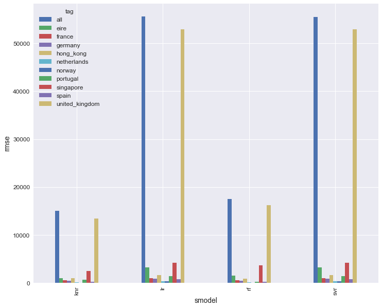

```python
# select the ones trained with all the data (test=False)
train_logs_all = train_logs.loc[train_logs.test_data != True,:]

# Drop duplicate model results (using same clf)
train_logs_all = train_logs_all.drop_duplicates(subset=['tag','smodel'],
                                                keep="first")
print("... {} models where trained with all data".format(train_logs_all.shape[0]))

filename = os.path.join(IMG_DIR, 'train_rmse.png')
plot_multiple_bar_graph(train_logs_all, 'smodel', 'rmse', 'tag', filename)
```